# CP 05 COLGATE - CREST

German de los Mozos

21/11/2020

El objetivo es predecir las 16 semanas del año 1963, para las dos cuotas de mercado, por lo que se dejará fuera de la muestra este periodo muestral.

El análisis debe incluir para las dos series la estimación de un modelo ARIMA, la detección de atípicos/outlier y un modelo de interveción. Por último se debe realizar un modelo de función de tranferencia entre las dos cuotas.

## Breve EDA

```r
skim(df)
```

Data summary

| Name | df |
| --- | --- |
| Number of rows | 276 |
| Number of columns | 5 |
| _______________________ |  |
| Column type frequency: |  |
| Date | 1 |
| numeric | 4 |
| ________________________ |  |
| Group variables | None |

**Variable type: Date**

| skim_variable | n_missing | complete_rate | min | max | median | n_unique |
| --- | --- | --- | --- | --- | --- | --- |
| Fecha | 0 | 1 | 1958-01-06 | 1963-04-22 | 1960-08-25 | 276 |

**Variable type: numeric**

| skim_variable | n_missing | complete_rate | mean | sd | p0 | p25 | p50 | p75 | p100 | hist |
| --- | --- | --- | --- | --- | --- | --- | --- | --- | --- | --- |
| Year | 0 | 1 | 1960.17 | 1.54 | 1958.00 | 1959.00 | 1960.00 | 1961.00 | 1963.00 | ▇▃▃▃▁ |
| Week | 0 | 1 | 25.46 | 15.23 | 1.00 | 12.00 | 25.00 | 39.00 | 52.00 | ▇▇▆▆▇ |
| Crest | 0 | 1 | 0.26 | 0.13 | 0.05 | 0.13 | 0.25 | 0.37 | 0.53 | ▇▅▃▇▂ |
| Colgate | 0 | 1 | 0.31 | 0.07 | 0.16 | 0.26 | 0.31 | 0.36 | 0.50 | ▂▇▇▅▁ |

## Separamos los datos tanto de colgate como de Crest.

#### Convertimos los datos a formato zoo para poder trabajarlos mejor

#### Graficamos ambas series

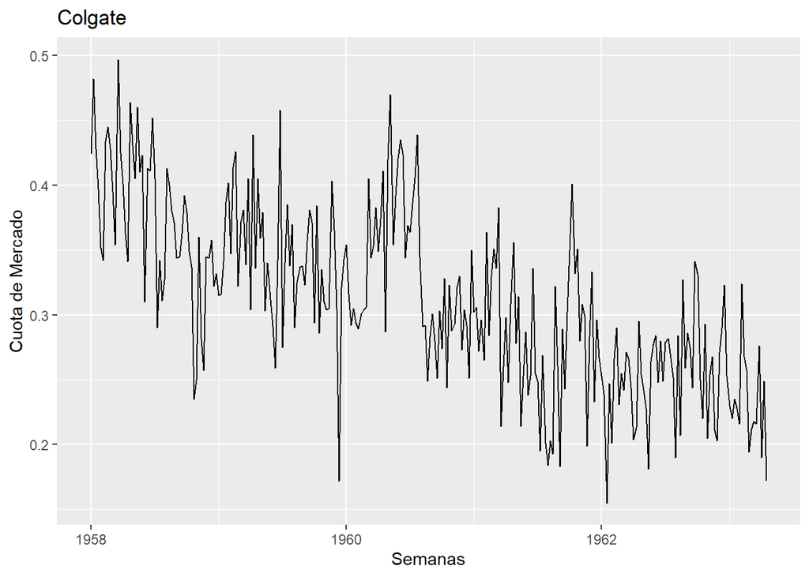

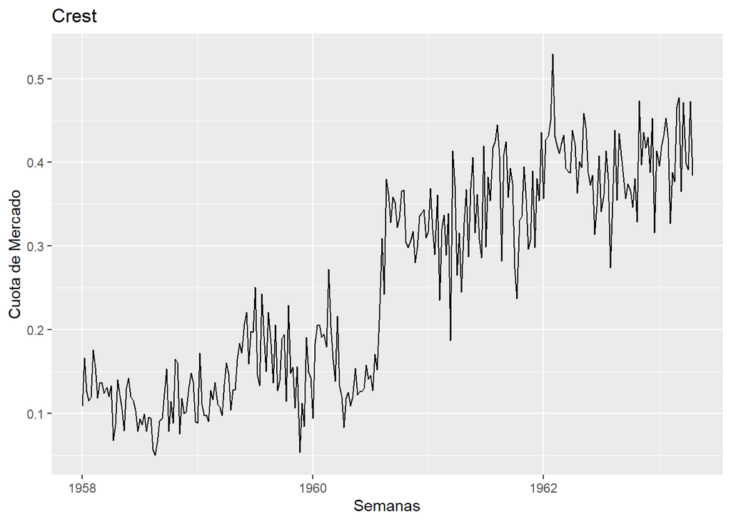

##### A continuación mediante el test Dickey AFuller comprobartemos la posible existencia dentro en las series

```r
adf.test(acolgate)
```

```
##
##  Augmented Dickey-Fuller Test
##
## data:  acolgate
## Dickey-Fuller = -4.1783, Lag order = 6, p-value = 0.01
## alternative hypothesis: stationary
```

```r
adf.test(acrest)
```

```
##
##  Augmented Dickey-Fuller Test
##
## data:  acrest
## Dickey-Fuller = -3.4715, Lag order = 6, p-value = 0.04591
## alternative hypothesis: stationary
```

#### Eliminamos las semanas correspondientes al año 1963 las cuales formarán parte de nuestro test

#### Seleccionamos el train

Modelo ARIMA

Los conjuntos de datos de series cronológicas pueden contener tendencias y estacionalidad, que tal vez sea necesario eliminar antes de la elaboración de modelos.

Las tendencias pueden dar lugar a una media variable a lo largo del tiempo, mientras que la estacionalidad puede dar lugar a una variación cambiante a lo largo del tiempo, lo que define a una serie temporal como no estacionaria.

Los conjuntos de datos estacionarios son los que tienen una media y una varianza estables, y a su vez son mucho más fáciles de modelar. Por ello, vamos a hacer nuestras series estacionarias.

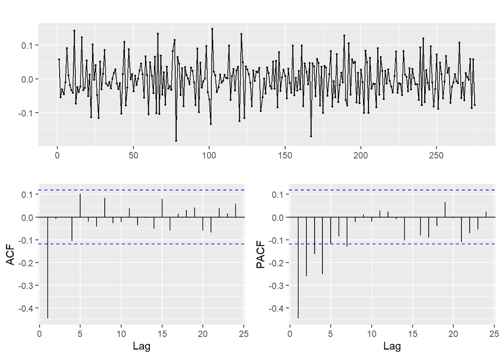

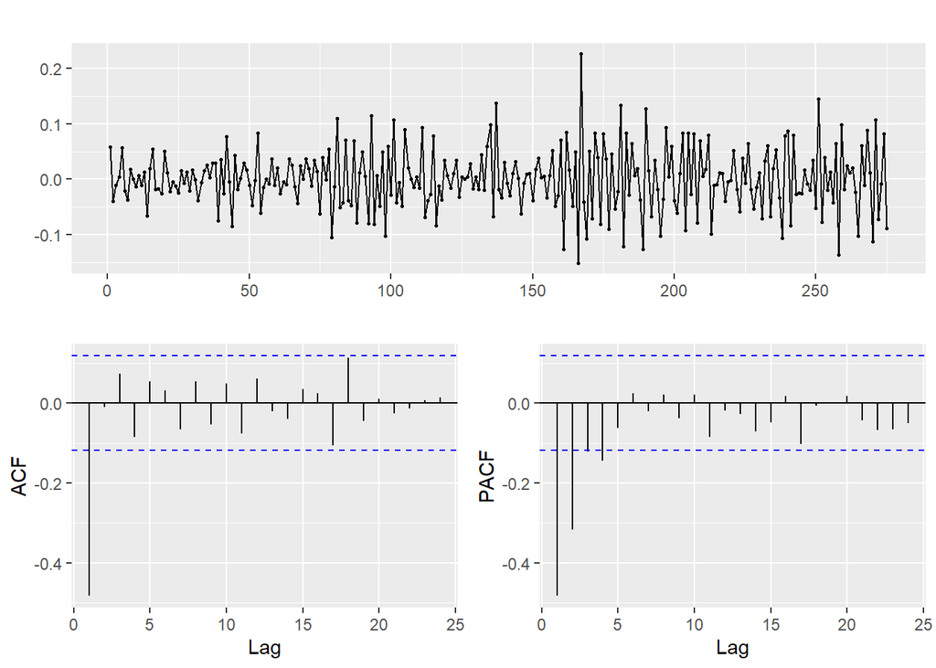

## Selección del lambda

Para seleccionar el lambda lo miramos por el BoxCox

```
## Series: colgatet
## ARIMA(0,1,1)
## Box Cox transformation: lambda= 0.2496041
##
## Coefficients:
##           ma1
##       -0.7650
## s.e.   0.0477
##
## sigma^2 estimated as 0.01387:  log likelihood=186.55
## AIC=-369.09   AICc=-369.05   BIC=-361.98
##
## Training set error measures:
##                         ME      RMSE        MAE       MPE     MAPE      MASE
## Training set -0.0005424343 0.0479128 0.03783284 -2.367426 12.74197 0.6053254
##                    ACF1
## Training set 0.05703632
```

```
## Series: crestt
## ARIMA(0,1,1)
## Box Cox transformation: lambda= 0.5803491
##
## Coefficients:
##           ma1
##       -0.6396
## s.e.   0.0452
##
## sigma^2 estimated as 0.006994:  log likelihood=275.4
## AIC=-546.8   AICc=-546.76   BIC=-539.69
##
## Training set error measures:
##                       ME       RMSE      MAE       MPE     MAPE      MASE
## Training set 0.004125602 0.04538404 0.034642 -2.278906 17.21842 0.3821147
##                    ACF1
## Training set -0.0510282
```

El modelo ARIMA que se estima para la serie de Crest es en la parte parte regular se ha tenido que aplicar 1 diferencia para hacerlo estacionario y una media móvil de orden 1. Y sin estructura en la parte estacional.

#### Gráficos de los residuos

Lo que nos interesa es que los errores sean ruido blanco.

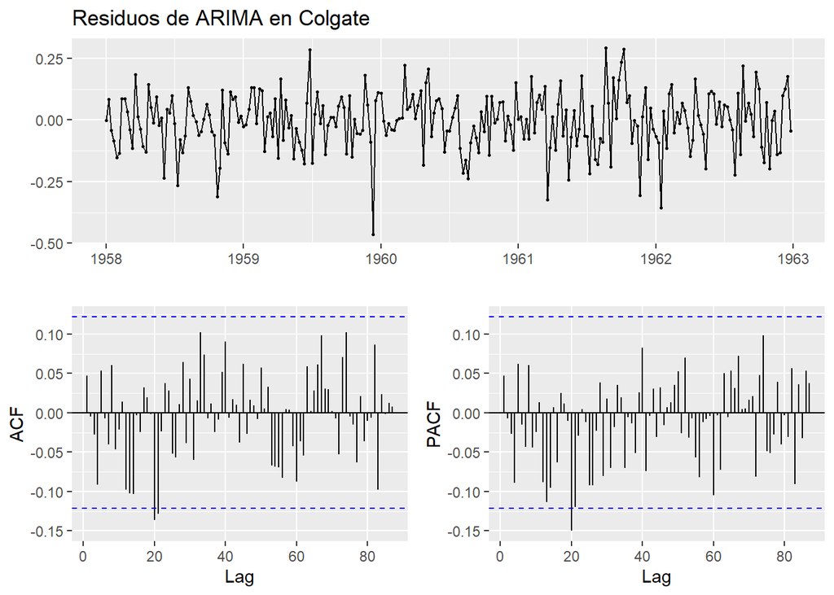

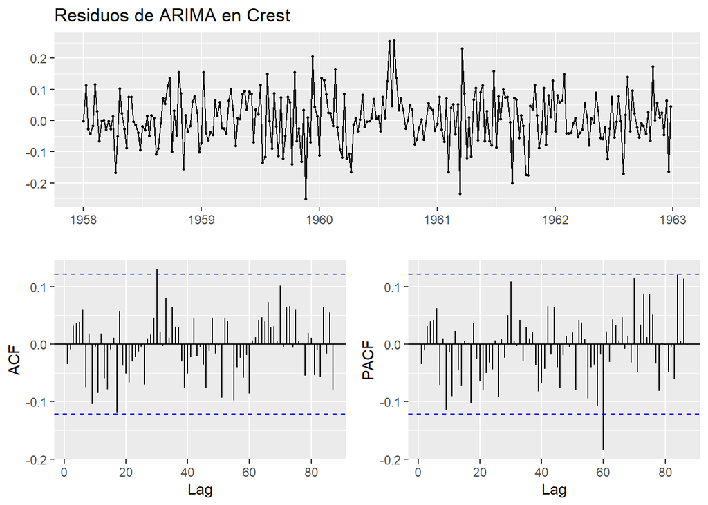

## Análisis de los Residuos

```r
#box-Ljung Test
Box.test(fit_colgate$residuals,lag=4, fitdf=3, type="Lj")
```

```
##
##  Box-Ljung test
##
## data:  fit_colgate$residuals
## X-squared = 3.021, df = 1, p-value = 0.08219
```

No rechazamosla hipótesis nula, ya que el p-value es mayor a 0.05 que indica que nuestro error es ruido blanco.

```r
jb.norm.test(fit_colgate$residuals, nrepl=200000)
```

```
##
##  Jarque-Bera test for normality
##
## data:  fit_colgate$residuals
## JB = 11.84, p-value = 0.009565
```

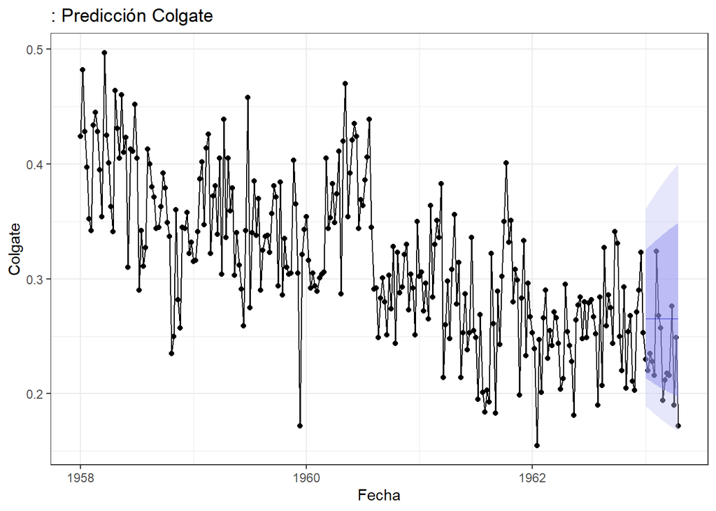

```r
#Predecimos los meses
fColgate.arima<-forecast(fit_colgate,h=16)#horizonte de 16 semanas
df_new <- data.frame(value = as.vector(acolgate), time = time(acolgate))
ggplot(df_new)+geom_point(aes(x=time,y=value))+geom_line(aes(x=time,y=value))+ geom_forecast(fColgate.arima,alpha=0.4)+xlab("Fecha")+ylab("Colgate")+ggtitle(": Predicción Colgate") + theme_bw()
```

```r
fColgate.arima
```

```
##          Point Forecast     Lo 80     Hi 80     Lo 95     Hi 95
## 1963.000      0.2651575 0.2136583 0.3254548 0.1896480 0.3612580
## 1963.019      0.2651575 0.2123699 0.3272293 0.1878485 0.3641959
## 1963.038      0.2651575 0.2111204 0.3289649 0.1861079 0.3670751
## 1963.058      0.2651575 0.2099069 0.3306645 0.1844217 0.3698999
## 1963.077      0.2651575 0.2087269 0.3323306 0.1827861 0.3726743
## 1963.096      0.2651575 0.2075781 0.3339656 0.1811977 0.3754017
## 1963.115      0.2651575 0.2064586 0.3355714 0.1796533 0.3780851
## 1963.135      0.2651575 0.2053664 0.3371498 0.1781502 0.3807274
## 1963.154      0.2651575 0.2042999 0.3387025 0.1766859 0.3833310
## 1963.173      0.2651575 0.2032578 0.3402309 0.1752583 0.3858982
## 1963.192      0.2651575 0.2022386 0.3417365 0.1738651 0.3884309
## 1963.212      0.2651575 0.2012411 0.3432203 0.1725046 0.3909311
## 1963.231      0.2651575 0.2002642 0.3446836 0.1711752 0.3934005
## 1963.250      0.2651575 0.1993068 0.3461273 0.1698751 0.3958406
## 1963.269      0.2651575 0.1983681 0.3475524 0.1686030 0.3982529
## 1963.288      0.2651575 0.1974471 0.3489598 0.1673575 0.4006386
```

[figure not shown]

[output not shown]

En este caso una función escalón, que genera un impulso positivo ascendente.

## Outliers

Obtenemos los outliers aditivos e innovativos

```
## [1] "No AO detected"
```

```
##               [,1]       [,2]
## ind     135.000000 136.000000
## lambda2   3.859664   4.164304
```

```
##               [,1]
## ind     102.000000
## lambda1  -4.055339
```

```
## [1] "No IO detected"
```

## ARIMAX

```
##
## Call:
## arimax(x = as.double(acolgate), order = c(0, 1, 1), method = "ML", xtransf = data.frame(A60_step = 1 *
##     (seq(acolgate) > 102), A60_pulse = 1 * (seq(acolgate) == 102)), transfer = list(c(0,
##     0), c(1, 0)))
##
## Coefficients:
##           ma1  A60_step-MA0  A60_pulse-AR1  A60_pulse-MA0
##       -0.7562       -0.0092         0.0236        -0.1633
## s.e.   0.0459        0.0341         0.2510         0.0465
##
## sigma^2 estimated as 0.002162:  log likelihood = 453.16,  aic = -898.33
```

Graficamos el ajuste

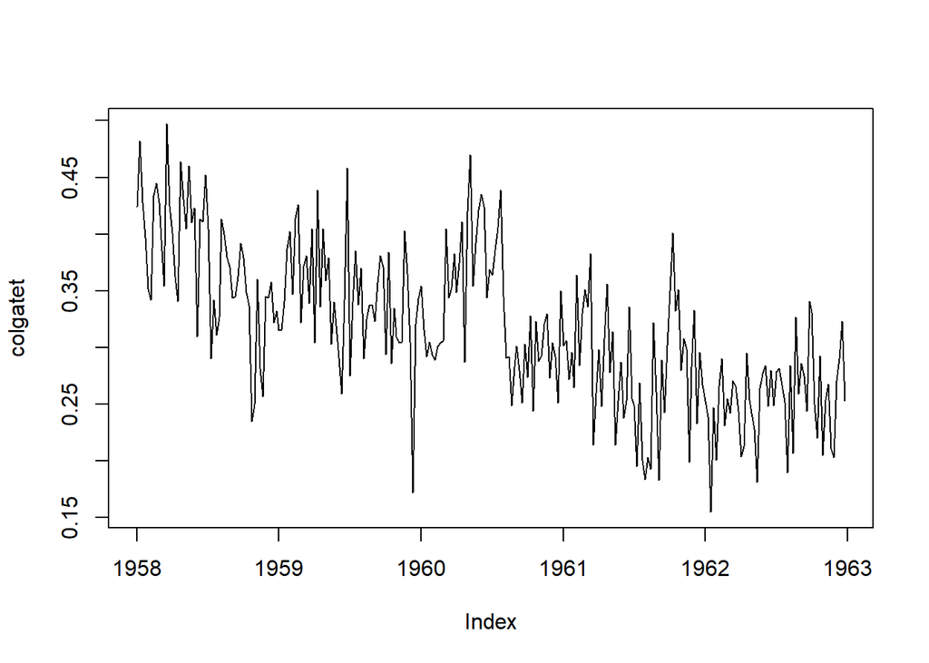

```
##           ma1  A60_step-MA0 A60_pulse-AR1 A60_pulse-MA0
##  -0.756225183  -0.009168192   0.023564931  -0.163286079
```

```
##
## Call:
## arimax(x = as.double(crestt), order = c(0, 1, 1), xreg = data.frame(A60_2 = 1 *
##     (seq(crestt) == c(135, 136))), method = "ML", xtransf = data.frame(A60_step = 1 *
##     (seq(crestt)), A60_pulse = 1 * (seq(crestt))), transfer = list(c(0, 0),
##     c(1, 0)))
##
## Coefficients:
```

```
##           ma1   A60_2  A60_step-MA0  A60_pulse-AR1  A60_pulse-MA0
##       -0.6550  0.0261         5e-04         0.0000          5e-04
## s.e.   0.0455  0.0319           NaN         0.0013            NaN
##
## sigma^2 estimated as 0.002032:  log likelihood = 434.97,  aic = -859.94
```

```
## [1] "No AO detected"
```

```
## [1] "No IO detected"
```

```
##               [,1]       [,2]
## ind     136.000000 138.000000
## lambda2   4.270706   4.192617
```

```
## [1] "No IO detected"
```

# Función de transferencia

Colgate en función de crest

```
##
## Call:
## arimax(x = as.double(colgatet), order = c(0, 1, 1), include.mean = TRUE, method = "ML",
##     xtransf = crestt, transfer = list(c(0, 0)))
##
## Coefficients:
##           ma1  xtransf-MA0
##       -0.8345      -0.4946
## s.e.   0.0362       0.0551
##
## sigma^2 estimated as 0.001776:  log likelihood = 452.04,  aic = -900.08
```

Graficamos los residuos.

```
##
## Call:
## arimax(x = as.double(colgatet), order = c(0, 1, 1), include.mean = TRUE, method = "ML",
##     xtransf = crestt, transfer = list(c(0, 0)))
##
## Coefficients:
##           ma1  xtransf-MA0
##       -0.8345      -0.4946
## s.e.   0.0362       0.0551
##
## sigma^2 estimated as 0.001776:  log likelihood = 452.04,  aic = -900.08
##
## Training set error measures:
##                         ME       RMSE        MAE       MPE     MAPE      MASE
## Training set -0.0006685206 0.04206675 0.03255199 -1.869282 10.83969 0.6975235
##                    ACF1
## Training set 0.07859318
```

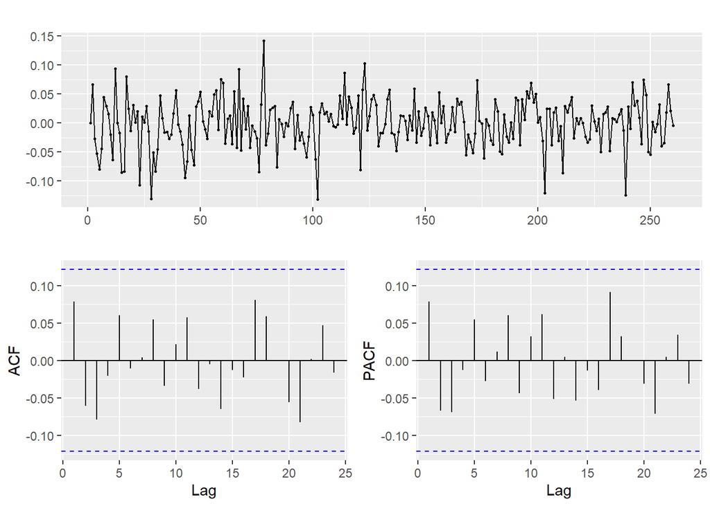

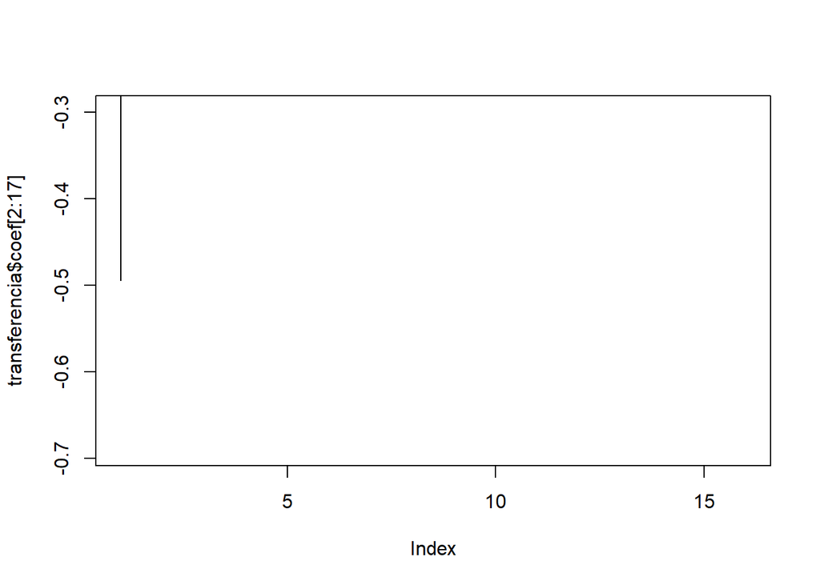